# Beating the Spread

Michael Williams

# Introduction

Sports betting is the subject of much scrutiny from statisticians because it is one of the few forms of betting where bettors have some agency in their choice. Consider the differnece between picking red or black to win in roulette and picking the winner of the NBA finals this year, in the former you pick entirely blindly and in the latter you consult prior knowledge to make a prediction about a future outcome. The most common form of sports betting is termed ‘betting the spread’. In this form of betting an oddsmaker sets a value to add to the final score of the home team (can be negative), if the bettor selects the winner of this modified contest properly then they recieve their bet back plus near-equal winnings (more on this later). This form of betting is popular in points-based sports because it is meant to give about a 50-50 chance of winning, which tends to appeal to bettors (The other options being short odds that require betting a lot of money to get little back and long odds which pay out a lot of money but are unlikely to win). In the event of a tie (after spread adjustment), the game is considered a ‘push’ and bets are returned with no winnings.

One common misconception is that an oddsmaker sets the spread based on what they think will occur. In reality, oddsmakers seek to set the spread in such a way as to create a ‘balanced book’. This means that the total amount of money bet on team A and team B is the same. The important repurcussion of this fact is that a bettor is not trying to beat the oddsmakers, but rather the betting public. If the oddsmakers do create a balanced book then how do they make money? The payout for a USD110 bet is generally USD100. This means that the oddsmakers will always make money on a balanced book. The goal of the bettor then is to pick well enough that they win enough to make up for this differential or abstain from betting until favorable betting conditions arise. The goal of this project is to identify such a favorable condition.

NFL teams play half of their games at their home stadium and half of their games at away stadiums. Stadiums are spread out across the United States and can be relied upon to have vastly different weather conditions. In December, a Miami Dolphins team may have to get on a plane in Florida and travel to Foxborough, Massachussetts to play the New England Patriots. The difficulty that this change of climate imposes could impact the performance of the Dolphins in a way that the bettors do not consider. My hypothesis is that teams like the New England Patriots (termed cold-weather teams) will have an unaccounted-for advantage when playing at home in the winter (defined as November and December) against teams like the Miami Dolphins (termed warm-weather teams).

Formally, my hypothesis is that the number of spread-wins for cold-weather home teams is greater than the number of spread-losses when facing warm-weather away opponents.  
$H_a: W - L > 0$

The alternative hypothesis is that the number of spread-wins and spread-losses is the same.  
$H_o: W - L = 0$

Since I can only observe W-L for my full dataset a single time I will use randomization to determine the proability of observing as extreme a value under the null hypothesis. This probability will serve as my p value.  
$p = P(W_{obs}-L_{obs} < W_{sim}-L_{sim})$

# The data

The data for this study was taken from the oddsshark.com searchable NFL archive ([link](http://www.oddsshark.com/nfl/database)). The following image shows an example search result; it is the last six games played in San Francisco, their outcomes, and their spreads.

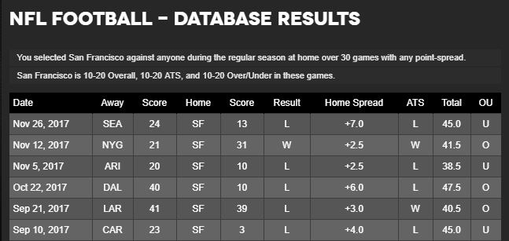

# Exploratory Analysis

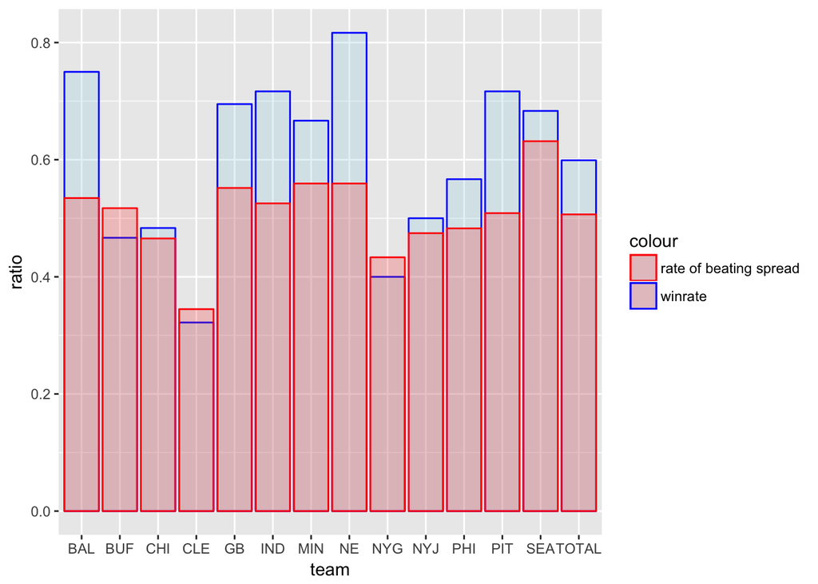

Interestingly, our home teams are winning about 60% of their games, although the spread is working at a very accurate rate of 0.507. The New England Patriots have won at an impressive 0.817 rate and the Cleveland Browns at an abysmal 0.322 rate which gives me confidence that this data is accurate.

# Results

Now I’ll display the same visualization restricted to warm-weather away teams. See Appendix B for code.

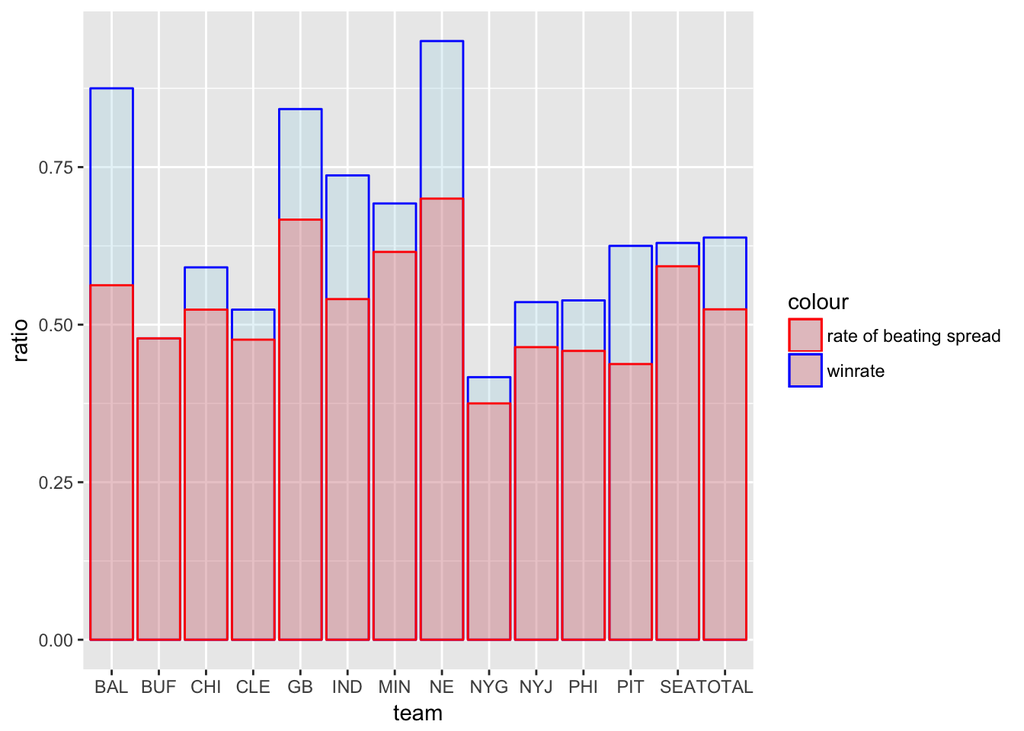

With all of our selection criteria applied, we see a slight change in the total spread-win rate, it is now 0.524. The total spread-wins in this dataset is 151 and the total spread-losses is 137. This is a positive result but is it statistically significant? What is the likelihood that the actual rate at which cold-weather teams beat the spread against warm-weather teams is 0.5 and these results are simply a sample from that null distribution? In order to test this I will simulate 10,000 288 game samples where the true probability for the home team to beat the spread is 0.5, I will then compare my observed results to the simulated ones. The following is a histogram of the win differential in simulated game sets (theoretical expected value = 0) with a red line marking the observed win differential. See Appendix C for code.

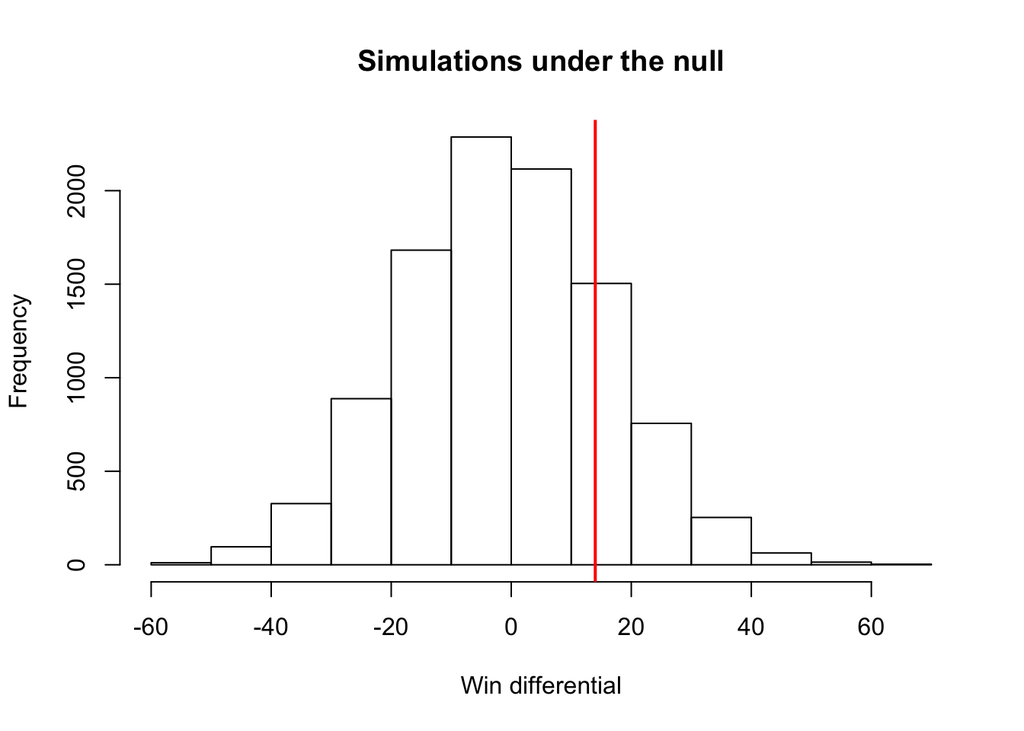

The probability of observing a simulated result as strong as the observed is 0.188.

# Discussion

The p value calculated from comparing the observed win differential to the null distribution is not very convincing. If there is a 20% chance that I can observe what I did under the Null then I am hardly willing to risk money on a bet. Indeed, if I only win USD100 for every USD110 successfully wagered then I need a true spread-win ratio of 0.524 to even break even (the observed rate was exactly 0.524).

The study also suffers from a limitation regarding the historical spreads. I’m using the post hoc estimate of the spread according to one website. In reality spreads are dynamic and the actual spreads a person would have bet would surely be different from the ones used in this study.

The condition that I examined is imperfect as well. My goal was to pick an exposure that would be poorly accounted for by the betting public, maybe the effect of cold weather is in fact overestimated by the public and the actual correct scheme is to bet against the home team under such conditions. In the future I intend to analyze similar data sets with more obscure criteria to try to find an edge in betting. If I can find a scheme that outperforms the simulations under the null 95% of the time with an observed spread-win rate of at least 0.6 then I’ll develop a betting scheme from that and see how it performs next season.

# Appendix A

```r
#This code generates the Exploratory Analysis plot
library(ggplot2)
filepath <- "C:/Users/Michael/Desktop/6311 proj/resultscsv.csv"
x<- read.csv(filepath , stringsAsFactors = FALSE)
colnames(x) <- c('date' , 'away' , 'awayscore' , 'home' , 'homescore' , 'homewl' , 'spread' , 'homevspread' , 'total' , 'ou')

#Some exploration of stats
totalpush <- sum(x$homevspread == 'P')
totalwin <- sum(x$homevspread == 'W')
totalloss <- sum(x$homevspread == 'L')

#make and fill df for exploratory data
byteam <- data.frame(team = unique(x$home) , winr = rep(NA , length(unique(x$home))) , sprr = rep(NA , length(unique(x$home))))
for (i in 1:length(unique(x$home))) {
  n <- as.character(byteam$team[i])
  byteam$winr[i] <- sum(x[x$home == n,]$homewl == 'W') / (sum(x[x$home == n,]$homewl == 'L') + sum(x[x$home == n,]$homewl == 'W'))
  byteam$sprr[i] <- sum(x[x$home == n,]$homevspread == 'W') / (sum(x[x$home == n,]$homevspread == 'L') + sum(x[x$home == n,]$homevspread == 'W'))
}
byteam <- rbind(byteam,data.frame(team='TOTAL',winr=sum(x$homewl == 'W') / (sum(x$homewl == 'W') + sum(x$homewl == 'L')) ,sprr=sum(x$homevspread == 'W') / (sum(x$homevspread == 'W') + sum(x$homevspread == 'L'))))

#Plot of all the raw winrates and spread beating rates
ggplot(data = byteam) + geom_bar(aes(x=team, y = winr , color ='winrate') ,stat = 'identity', alpha = .3, fill ='lightblue') + geom_bar(aes(x=team,y = sprr , color ='rate of beating spread', alpha = .2) ,stat = 'identity', alpha = .2 , fill ='red') + labs(y = 'ratio') + scale_color_manual(values = c('red','blue'))
```

# Appendix B

```r
#Plot only the games of interest
warmteams <- c('MIA','JAC','TB','CAR','ATL','TEN','NO','HOU','DAL','ARI','SD','SF','LAR','OAK')
nvs <- x[x$away %in% warmteams,]

totalpush <- sum(nvs$homevspread == 'P')
totalwinvspread <- sum(nvs$homevspread == 'W')
totallossvspread <- sum(nvs$homevspread == 'L')

#make and fill df for presentation
res <- data.frame(team = unique(nvs$home) , winr = rep(NA , length(unique(nvs$home))) , sprr = rep(NA , length(unique(nvs$home))) , nw= rep(NA , length(unique(nvs$home))) , nl = rep(NA , length(unique(nvs$home))) )
for (i in 1:length(unique(nvs$home))) {
  n <- as.character(res$team[i])
  res$winr[i] <- sum(nvs[nvs$home == n,]$homewl == 'W') / (sum(nvs[nvs$home == n,]$homewl == 'L') + sum(nvs[nvs$home == n,]$homewl == 'W'))
  res$sprr[i] <- sum(nvs[nvs$home == n,]$homevspread == 'W') / (sum(nvs[nvs$home == n,]$homevspread == 'L') + sum(nvs[nvs$home == n,]$homevspread == 'W'))
  res$nw[i] <- sum(nvs[nvs$home == n,]$homevspread == 'W')
  res$nl[i] <- sum(nvs[nvs$home == n,]$homevspread == 'L')
}
res <- rbind(res , data.frame(team='TOTAL',winr=sum(nvs$homewl == 'W') / (sum(nvs$homewl == 'W') + sum(nvs$homewl == 'L')) ,sprr=sum(nvs$homevspread == 'W') / (sum(nvs$homevspread == 'W') + sum(nvs$homevspread == 'L')) , nw = sum(nvs$homevspread == 'W') , nl = sum(nvs$homevspread == 'L')))

#Plot of all the raw winrates and spread beating rates
ggplot(data = res) + geom_bar(aes(x=team, y = winr , color ='winrate') ,stat = 'identity', alpha = .3, fill ='lightblue') + geom_bar(aes(x=team,y = sprr , color ='rate of beating spread', alpha = .2) ,stat = 'identity', alpha = .2 , fill ='red') + labs(y = 'ratio') + scale_color_manual(values = c('red','blue'))
```

# Appendix C

```r
#test hypothesis by randomization
ngames <- sum(nvs$homevspread == 'L') + sum(nvs$homevspread == 'W')
loops <- 10000
simwin <- rep(NA,loops)
for (i in 1:loops) {
  simwin[i] <- rbinom(1,ngames,.5)
  simwin[i] <- simwin[i] - (ngames - simwin[i])
}

obswin <- tail(res$nw,1) - tail(res$nl,1)

a <- sum(obswin < simwin) / loops

hist(simwin , main = 'Simulations under the null' , xlab = 'Win differential') ; abline(v=obswin,col="red", lwd = 2)
```